This demonstration is about clustering using **Kmeans** and also determining the optimal number of clusters (k) using **Silhouette Method**.

#### Dataset

This data set is taken from UCI Machine Learning Repository. The data set refers to clients of a wholesale distributor. It includes the annual spending in monetary units (m.u.) on diverse product categories

Attribute Information:

1. FRESH: annual spending (m.u.) on fresh products (Continuous);
2. MILK: annual spending (m.u.) on milk products (Continuous);
3. GROCERY: annual spending (m.u.)on grocery products (Continuous);
4. FROZEN: annual spending (m.u.)on frozen products (Continuous)
5. DETERGENTS_PAPER: annual spending (m.u.) on detergents and paper products (Continuous)
6. DELICATESSEN: annual spending (m.u.)on and delicatessen products (Continuous);
7. CHANNEL: customers Channel - Horeca (Hotel/Restaurant/Cafe) or Retail channel (Nominal)
8. REGION: customers Region Lisnon, Oporto or Other (Nominal)

#### Loading the libraries

`cluster` library is loaded for clustering algorithms and `factoextra` is loaded for visualization.

```r
# install.packages('corrplot')
library(corrplot)
# Clustering
library(cluster)
library(factoextra)
```

#### Loading Data set

```r
data <- read.csv('Wholesale customers data.csv', header = TRUE)
head(data,5)
```

|  | Channel | Region | Fresh | Milk | Grocery | Frozen | Detergents_Paper | Delicassen |
| --- | --- | --- | --- | --- | --- | --- | --- | --- |
| 1 | 2 | 3 | 12669 | 9656 | 7561 | 214 | 2674 | 1338 |
| 2 | 2 | 3 | 7057 | 9810 | 9568 | 1762 | 3293 | 1776 |
| 3 | 2 | 3 | 6353 | 8808 | 7684 | 2405 | 3516 | 7844 |
| 4 | 1 | 3 | 13265 | 1196 | 4221 | 6404 | 507 | 1788 |
| 5 | 2 | 3 | 22615 | 5410 | 7198 | 3915 | 1777 | 5185 |

#### EDA

- Structure of data
- Summary statistics
- Correlation Plot

```r
data <- na.omit(data)
str(data)
```

```
'data.frame':   440 obs. of  8 variables:
 $ Channel         : int  2 2 2 1 2 2 2 2 1 2 ...
 $ Region          : int  3 3 3 3 3 3 3 3 3 3 ...
 $ Fresh           : int  12669 7057 6353 13265 22615 9413 12126 7579 5963 6006 ...
 $ Milk            : int  9656 9810 8808 1196 5410 8259 3199 4956 3648 11093 ...
 $ Grocery         : int  7561 9568 7684 4221 7198 5126 6975 9426 6192 18881 ...
 $ Frozen          : int  214 1762 2405 6404 3915 666 480 1669 425 1159 ...
 $ Detergents_Paper: int  2674 3293 3516 507 1777 1795 3140 3321 1716 7425 ...
 $ Delicassen      : int  1338 1776 7844 1788 5185 1451 545 2566 750 2098 ...
```

```r
summary(data)
```

```
    Channel          Region          Fresh             Milk          Grocery
 Min.   :1.000   Min.   :1.000   Min.   :     3   Min.   :   55   Min.   :    3
 1st Qu.:1.000   1st Qu.:2.000   1st Qu.:  3128   1st Qu.: 1533   1st Qu.: 2153
 Median :1.000   Median :3.000   Median :  8504   Median : 3627   Median : 4756
 Mean   :1.323   Mean   :2.543   Mean   : 12000   Mean   : 5796   Mean   : 7951
 3rd Qu.:2.000   3rd Qu.:3.000   3rd Qu.: 16934   3rd Qu.: 7190   3rd Qu.:10656
 Max.   :2.000   Max.   :3.000   Max.   :112151   Max.   :73498   Max.   :92780
     Frozen        Detergents_Paper    Delicassen
 Min.   :   25.0   Min.   :    3.0   Min.   :    3.0
 1st Qu.:  742.2   1st Qu.:  256.8   1st Qu.:  408.2
 Median : 1526.0   Median :  816.5   Median :  965.5
 Mean   : 3071.9   Mean   : 2881.5   Mean   : 1524.9
 3rd Qu.: 3554.2   3rd Qu.: 3922.0   3rd Qu.: 1820.2
 Max.   :60869.0   Max.   :40827.0   Max.   :47943.0
```

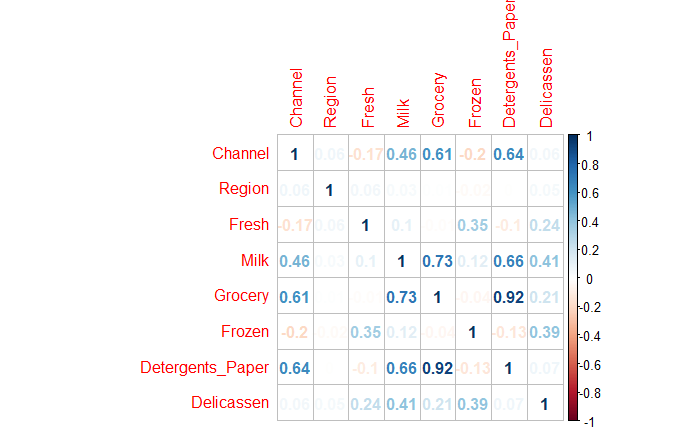

```r
corrmatrix <- cor(data)
corrplot(corrmatrix, method = 'number')
```

#### Data Preparation

All the attributes are of same scale except **“channel”** and **“region”**. We can ignore those attributes for clustering and normalization is not required.

```r
df <- data[-c(1,2)]
head(df,3)
```

|  | Fresh | Milk | Grocery | Frozen | Detergents_Paper | Delicassen |
| --- | --- | --- | --- | --- | --- | --- |
| 1 | 12669 | 9656 | 7561 | 214 | 2674 | 1338 |
| 2 | 7057 | 9810 | 9568 | 1762 | 3293 | 1776 |
| 3 | 6353 | 8808 | 7684 | 2405 | 3516 | 7844 |

### Clustering

#### Kmeans

Kmeans algorithm (also referred as Lloyd’s algorithm) is the most commonly used unsupervised machine learning algorithm used to partition the data into a set of k groups or clusters.

#### How Kmeans works?

1. Define the number of clusters (k).
2. Initialize k centroids by randomly.
3. **Assignment Step:** Assign each observation to the closest centroid (center-point) by calculting least squared euclidean distance between centroids and observations. (i.e. least squared euclidean distance between assigned center and observation should be minimum than other centers).
4. **Update Step:** Calculate the new means as centroids for new clusters.
5. Repeat both assignment and update step (i.e. steps 3 & 4) until convergence (minimum total sum of square) or maximum iteration is reached.

#### Determining optimal number of clusters (k)

Before we do the actual clustering, we need to identity the Optimal number of clusters (k) for this data set of wholesale customers. The popular way of determining number of clusters are

1. Elbow Method
2. **Silhouette Method**
3. Gap Static Method

Elbow and Silhouette methods are **direct** methods and gap statistic method is the **statistics** method.

In this demonstration, we are going to see how silhouette method is used.

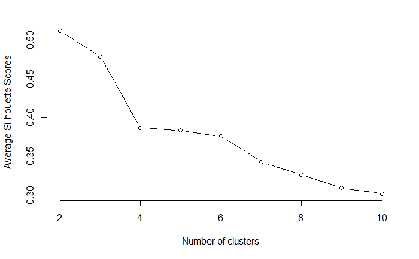

```r
silhouette_score <- function(k){
  km <- kmeans(df, centers = k, nstart=25)
  ss <- silhouette(km$cluster, dist(df))
  mean(ss[, 3])
}
k <- 2:10
avg_sil <- sapply(k, silhouette_score)
plot(k, type='b', avg_sil, xlab='Number of clusters', ylab='Average Silhouette Scores', frame=FALSE)
```

*Note:* The kmeans() function has an nstart option that attempts multiple initial configurations and reports on the best one. For example, adding nstart=25 will generate 25 initial configurations. This approach is often recommended.

The above method of calculating silhouette score using `silhouette()` and plotting the results states that **optimal number of clusters as 2**

The other method with visual aid is using `factoextra` package

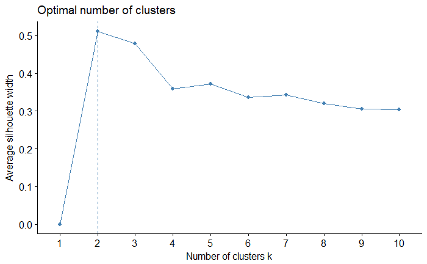

```r
fviz_nbclust(df, kmeans, method='silhouette')
```

**The optimal number of clusters is 2.**

#### Actual Clustering

```r
km.final <- kmeans(df, 2)
## Total Within cluster sum of square
km.final$tot.withinss
```

```
[1] 113217528521
```

```r
## Cluster sizes
km.final$size
```

```
[1]  65 375
```

```r
data$cluster <- km.final$cluster
head(data, 6)
```

|  | Channel | Region | Fresh | Milk | Grocery | Frozen | Detergents_Paper | Delicassen | cluster |
| --- | --- | --- | --- | --- | --- | --- | --- | --- | --- |
| 1 | 2 | 3 | 12669 | 9656 | 7561 | 214 | 2674 | 1338 | 2 |
| 2 | 2 | 3 | 7057 | 9810 | 9568 | 1762 | 3293 | 1776 | 2 |
| 3 | 2 | 3 | 6353 | 8808 | 7684 | 2405 | 3516 | 7844 | 2 |
| 4 | 1 | 3 | 13265 | 1196 | 4221 | 6404 | 507 | 1788 | 2 |
| 5 | 2 | 3 | 22615 | 5410 | 7198 | 3915 | 1777 | 5185 | 1 |
| 6 | 2 | 3 | 9413 | 8259 | 5126 | 666 | 1795 | 1451 | 2 |

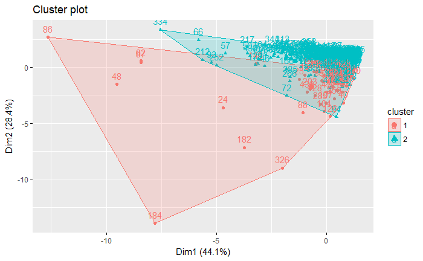

```r
fviz_cluster(km.final, data=df)
```

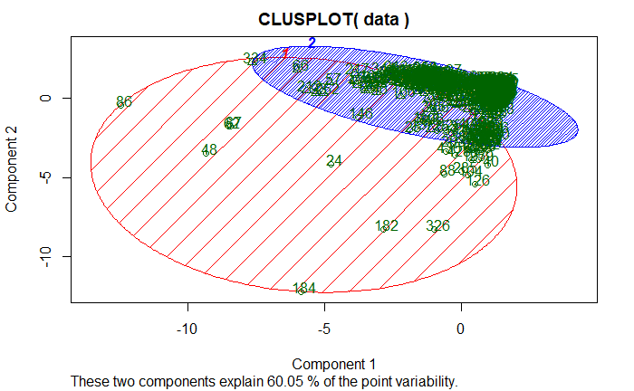

```r
clusplot(data, data$cluster, color=TRUE, shade = TRUE, label=2)
```

#### Conclusion

We had seen kmeans clustering of wholesale customers and how average silhouette measure is used to identify optimal number of clusters. In the next article, we will see about various other methods for determining optimal number of clusters. The code for this article is hosted [here.](https://github.com/jprakash0205/RDataScience)

#### References

1. https://home.deib.polimi.it/matteucc/Clustering/tutorial_html/kmeans.html
2. https://www.rdocumentation.org/packages/cluster/versions/2.0.7-1/topics/silhouette